# Movie Industry Project

By Jesse

##### In this I project I explore movie industry data and look for correlation between variables.

##### There are 6820 movies in the dataset (220 movies per year, 1986-2016). This data was scraped from IMDb.

#### Each movie has the following attributes:

- budget: the budget of a movie. Some movies don’t have this, so it appears as 0
- company: the production company
- country: country of origin
- director: the director
- genre: main genre of the movie.
- gross: revenue of the movie
- name: name of the movie
- rating: rating of the movie (R, PG, etc.)
- released: release date (YYYY-MM-DD)
- runtime: duration of the movie
- score: IMDb user rating
- votes: number of user votes
- star: main actor/actress
- writer: writer of the movie
- year: year of release

Let’s get started!

Loading in packages, removing objects from the environment and setting the working directory

```r
if (!require("pacman")) install.packages("pacman"); library(pacman)
pacman::p_load(tidyverse, caTools, lubridate,
               ggthemes, janitor, corrplot, GGally, psych)

rm(list=ls())
setwd("/Users/Jesse/R/MovieIndustryProject/")
```

Reading in the data

```r
df <- read_csv("/Users/Jesse/R/MovieIndustryProject/movies.csv")
```

Let’s take a took at the data

```r
head(df)
```

```
## # A tibble: 6 x 15
##    budget company   country director genre  gross name   rating released runtime
##     <dbl> <chr>     <chr>   <chr>    <chr>  <dbl> <chr>  <chr>  <chr>      <dbl>
## 1  8   e6 Columbia… USA     Rob Rei… Adve… 5.23e7 Stand… R      1986-08…      89
## 2  6   e6 Paramoun… USA     John Hu… Come… 7.01e7 Ferri… PG-13  1986-06…     103
## 3  1.5 e7 Paramoun… USA     Tony Sc… Acti… 1.80e8 Top G… PG     1986-05…     110
## 4  1.85e7 Twentiet… USA     James C… Acti… 8.52e7 Aliens R      1986-07…     137
## 5  9   e6 Walt Dis… USA     Randal … Adve… 1.86e7 Fligh… PG     1986-08…      90
## 6  6   e6 Hemdale   UK      Oliver … Drama 1.39e8 Plato… R      1987-02…     120
## # … with 5 more variables: score <dbl>, star <chr>, votes <dbl>, writer <chr>,
## #   year <dbl>
```

```r
str(df)
```

```
## spec_tbl_df [6,820 × 15] (S3: spec_tbl_df/tbl_df/tbl/data.frame)
##  $ budget  : num [1:6820] 8000000 6000000 15000000 18500000 9000000 6000000 25000000 6000000 9000000 15000000 ...
##  $ company : chr [1:6820] "Columbia Pictures Corporation" "Paramount Pictures" "Paramount Pictures" "Twentieth Century Fox Film Corporation" ...
##  $ country : chr [1:6820] "USA" "USA" "USA" "USA" ...
##  $ director: chr [1:6820] "Rob Reiner" "John Hughes" "Tony Scott" "James Cameron" ...
##  $ genre   : chr [1:6820] "Adventure" "Comedy" "Action" "Action" ...
##  $ gross   : num [1:6820] 5.23e+07 7.01e+07 1.80e+08 8.52e+07 1.86e+07 ...
##  $ name    : chr [1:6820] "Stand by Me" "Ferris Bueller's Day Off" "Top Gun" "Aliens" ...
##  $ rating  : chr [1:6820] "R" "PG-13" "PG" "R" ...
##  $ released: chr [1:6820] "1986-08-22" "1986-06-11" "1986-05-16" "1986-07-18" ...
##  $ runtime : num [1:6820] 89 103 110 137 90 120 101 120 96 96 ...
##  $ score   : num [1:6820] 8.1 7.8 6.9 8.4 6.9 8.1 7.4 7.8 6.8 7.5 ...
##  $ star    : chr [1:6820] "Wil Wheaton" "Matthew Broderick" "Tom Cruise" "Sigourney Weaver" ...
##  $ votes   : num [1:6820] 299174 264740 236909 540152 36636 ...
##  $ writer  : chr [1:6820] "Stephen King" "John Hughes" "Jim Cash" "James Cameron" ...
##  $ year    : num [1:6820] 1986 1986 1986 1986 1986 ...
##  - attr(*, "spec")=
##   .. cols(
##   ..   budget = col_double(),
##   ..   company = col_character(),
##   ..   country = col_character(),
##   ..   director = col_character(),
##   ..   genre = col_character(),
##   ..   gross = col_double(),
##   ..   name = col_character(),
##   ..   rating = col_character(),
##   ..   released = col_character(),
##   ..   runtime = col_double(),
##   ..   score = col_double(),
##   ..   star = col_character(),
##   ..   votes = col_double(),
##   ..   writer = col_character(),
##   ..   year = col_double()
##   .. )
```

Finally, let’s check for any missing values:

```r
any(is.na(df))
```

```
## [1] FALSE
```

No missing data! Let’s move on to basic data cleaning.

```r
df$year_corrected <- as.numeric(str_sub(df$released, 1, 4)) # fixing years not matching

df <- df %>% arrange(desc(gross)) # sorting by highest grossing movies
options(scipen = 999) # get rid of scientific notation

get_dupes(df)
```

```
## No variable names specified - using all columns.
```

```
## No duplicate combinations found of: budget, company, country, director, genre, gross, name, rating, released, ... and 7 other variables
```

```
## # A tibble: 0 x 17
## # … with 17 variables: budget <dbl>, company <chr>, country <chr>,
## #   director <chr>, genre <chr>, gross <dbl>, name <chr>, rating <chr>,
## #   released <chr>, runtime <dbl>, score <dbl>, star <chr>, votes <dbl>,
## #   writer <chr>, year <dbl>, year_corrected <dbl>, dupe_count <int>
```

```r
head(df)
```

```
## # A tibble: 6 x 16
##    budget company   country director genre  gross name   rating released runtime
##     <dbl> <chr>     <chr>   <chr>    <chr>  <dbl> <chr>  <chr>  <chr>      <dbl>
## 1  2.45e8 Lucasfilm USA     J.J. Ab… Acti… 9.37e8 Star … PG-13  2015-12…     136
## 2  2.37e8 Twentiet… UK      James C… Acti… 7.61e8 Avatar PG-13  2009-12…     162
## 3  2   e8 Twentiet… USA     James C… Drama 6.59e8 Titan… PG-13  1997-12…     194
## 4  1.5 e8 Universa… USA     Colin T… Acti… 6.52e8 Juras… PG-13  2015-06…     124
## 5  2.2 e8 Marvel S… USA     Joss Wh… Acti… 6.23e8 The A… PG-13  2012-05…     143
## 6  1.85e8 Warner B… USA     Christo… Acti… 5.35e8 The D… PG-13  2008-07…     152
## # … with 6 more variables: score <dbl>, star <chr>, votes <dbl>, writer <chr>,
## #   year <dbl>, year_corrected <dbl>
```

We created a new column to fix an issue with the release date and year not matching. Then we sort by highest grossing movies and check for any duplicates.

#### Looking for correlation

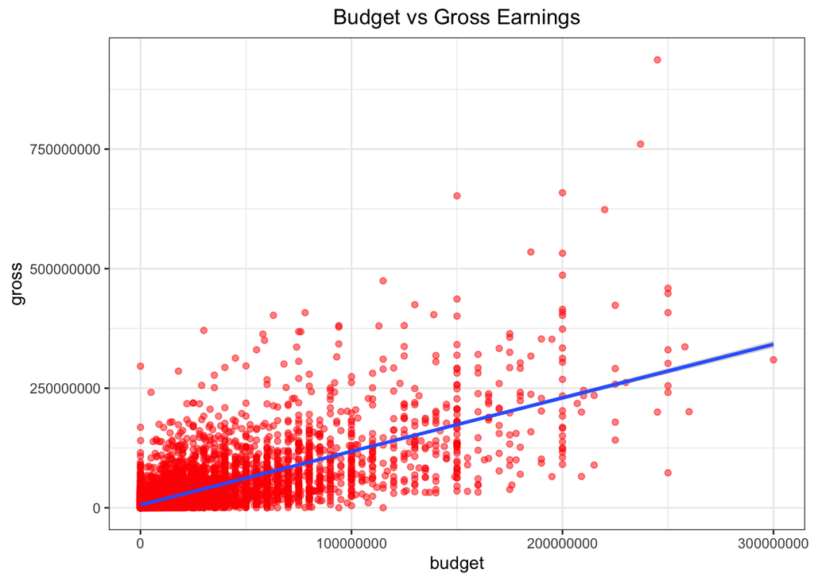

```r
df %>% ggplot(aes(budget, gross)) + geom_point(color = "red", alpha = .5) +
    ggtitle("Budget vs Gross Earnings",) + theme_bw() + theme(plot.title = element_text(hjust = .5)) +
    geom_smooth(method = "lm")
```

Above is a scatterplot showing the relationship between budget and gross earnings.

```r
df_cor <- df[,c(1,6,10,11,13,16)] # using only numeric features
cor(df_cor)
```

```
##                    budget     gross    runtime      score     votes
## budget         1.00000000 0.7121955 0.26822561 0.04214468 0.5039240
## gross          0.71219553 1.0000000 0.22457913 0.16569256 0.6624572
## runtime        0.26822561 0.2245791 1.00000000 0.39534306 0.3173994
## score          0.04214468 0.1656926 0.39534306 1.00000000 0.3936075
## votes          0.50392397 0.6624572 0.31739944 0.39360749 1.0000000
## year_corrected 0.27481959 0.1768787 0.08834229 0.11767939 0.2207968
##                year_corrected
## budget             0.27481959
## gross              0.17687872
## runtime            0.08834229
## score              0.11767939
## votes              0.22079678
## year_corrected     1.00000000
```

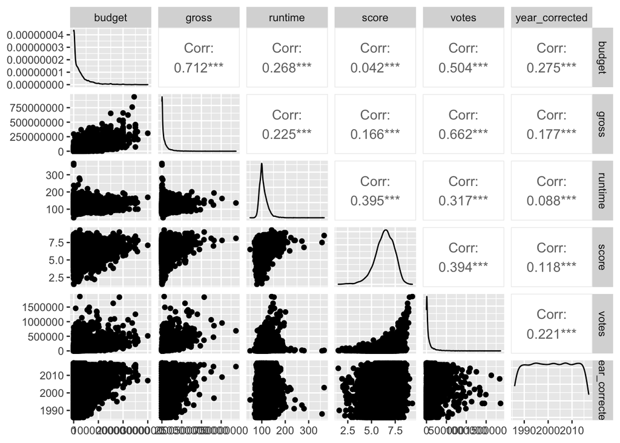

```r
ggpairs(df_cor) # matrix of plots
```

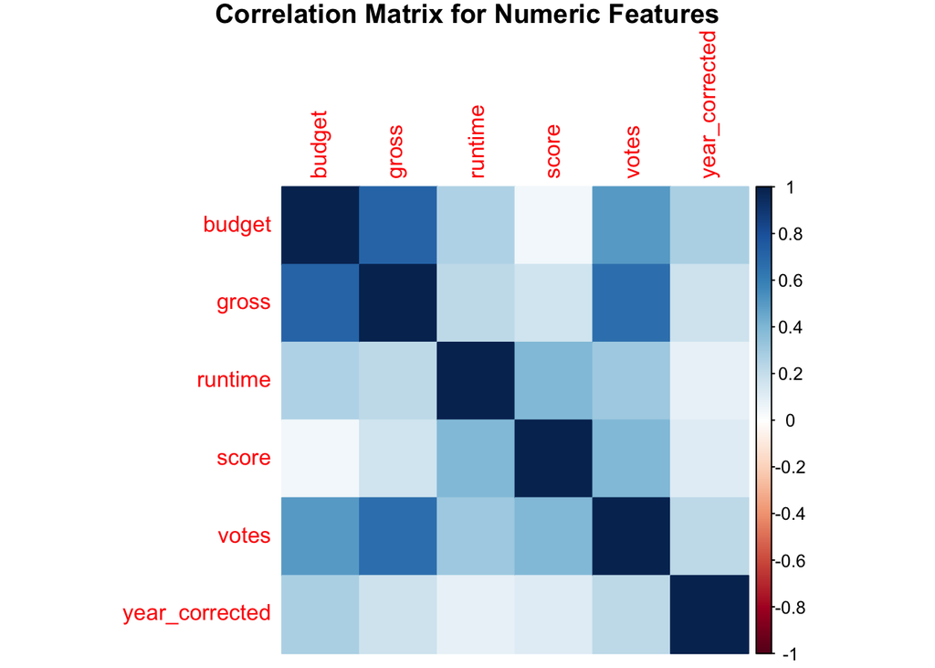

```r
cor_mx <- cor(df_cor)
corrplot(cor_mx,method = "color", title = "Correlation Matrix for Numeric Features",
         mar=c(0,0,1,0))
```

It looks like budget and votes have fairly strong positive correlation with gross earnings.

Next, let’s convert the character columns to factors then numeric values to be included in the correlation matrix

```r
# create numeric factor for all character columns
numeric_factor <- function(x){
    as.numeric(as.factor(x))
}

df_numfac <- df # creating frame to change characters to factored numeric values
df_numfac[,c(2:5,7,8,12,14)] <- lapply(df_numfac[,c(2:5,7,8,12,14)], numeric_factor) # converting non-numeric
                                                                                     # to factored numeric

cor(df_numfac[,c(-9,-15)]) # correlation with all features - removing old release date and release year
```

```
##                     budget      company      country     director         genre
## budget          1.00000000  0.187063860  0.140083933  0.011560217 -0.3467940273
## company         0.18706386  1.000000000  0.108934251  0.003170243 -0.0687294294
## country         0.14008393  0.108934251  1.000000000  0.003288812 -0.0439402044
## director        0.01156022  0.003170243  0.003288812  1.000000000 -0.0277171647
## genre          -0.34679403 -0.068729429 -0.043940204 -0.027717165  1.0000000000
## gross           0.71219553  0.187127932  0.152680021 -0.011461449 -0.2426764582
## name            0.02987158  0.019247805  0.026032118  0.002221202  0.0150186443
## rating         -0.11966012 -0.061948033  0.057895557  0.021965205  0.1009598099
## runtime         0.26822561  0.032827180 -0.083249532  0.026742414 -0.0413570627
## score           0.04214468 -0.009980956 -0.178286083  0.017055845  0.0562342413
## star           -0.01507873 -0.002861387 -0.014967413  0.039792761  0.0081382944
## votes           0.50392397  0.138610238  0.079604635  0.000608829 -0.1505188614
## writer         -0.01562788 -0.004763828  0.024721594  0.299008323 -0.0006658053
## year_corrected  0.27481959  0.028635589 -0.063888448  0.001865233 -0.0390139459
##                       gross          name        rating       runtime
## budget          0.712195533  0.0298715842 -0.1196601238  0.2682256069
## company         0.187127932  0.0192478049 -0.0619480330  0.0328271801
## country         0.152680021  0.0260321177  0.0578955569 -0.0832495316
## director       -0.011461449  0.0022212019  0.0219652052  0.0267424142
## genre          -0.242676458  0.0150186443  0.1009598099 -0.0413570627
## gross           1.000000000  0.0237865316 -0.1355376455  0.2245791256
## name            0.023786532  1.0000000000  0.0002174768  0.0152375202
## rating         -0.135537645  0.0002174768  1.0000000000  0.0795418431
## runtime         0.224579126  0.0152375202  0.0795418431  1.0000000000
## score           0.165692560  0.0236505729  0.0192707550  0.3953430562
## star            0.008370577 -0.0019845981  0.0078660513  0.0159715610
## votes           0.662457162  0.0239617774  0.0116783317  0.3173994369
## writer         -0.009471407  0.0101648900  0.0107717374  0.0007147906
## year_corrected  0.176878717  0.0227038415  0.0174380047  0.0883422876
##                       score         star        votes        writer
## budget          0.042144683 -0.015078729  0.503923973 -0.0156278787
## company        -0.009980956 -0.002861387  0.138610238 -0.0047638282
## country        -0.178286083 -0.014967413  0.079604635  0.0247215938
## director        0.017055845  0.039792761  0.000608829  0.2990083230
## genre           0.056234241  0.008138294 -0.150518861 -0.0006658053
## gross           0.165692560  0.008370577  0.662457162 -0.0094714068
## name            0.023650573 -0.001984598  0.023961777  0.0101648900
## rating          0.019270755  0.007866051  0.011678332  0.0107717374
## runtime         0.395343056  0.015971561  0.317399437  0.0007147906
## score           1.000000000  0.009459665  0.393607491  0.0121406906
## star            0.009459665  1.000000000 -0.011942095  0.0353520980
## votes           0.393607491 -0.011942095  1.000000000  0.0011429189
## writer          0.012140691  0.035352098  0.001142919  1.0000000000
## year_corrected  0.117679387 -0.026036247  0.220796779 -0.0044934092
##                year_corrected
## budget            0.274819594
## company           0.028635589
## country          -0.063888448
## director          0.001865233
## genre            -0.039013946
## gross             0.176878717
## name              0.022703842
## rating            0.017438005
## runtime           0.088342288
## score             0.117679387
## star             -0.026036247
## votes             0.220796779
## writer           -0.004493409
## year_corrected    1.000000000
```

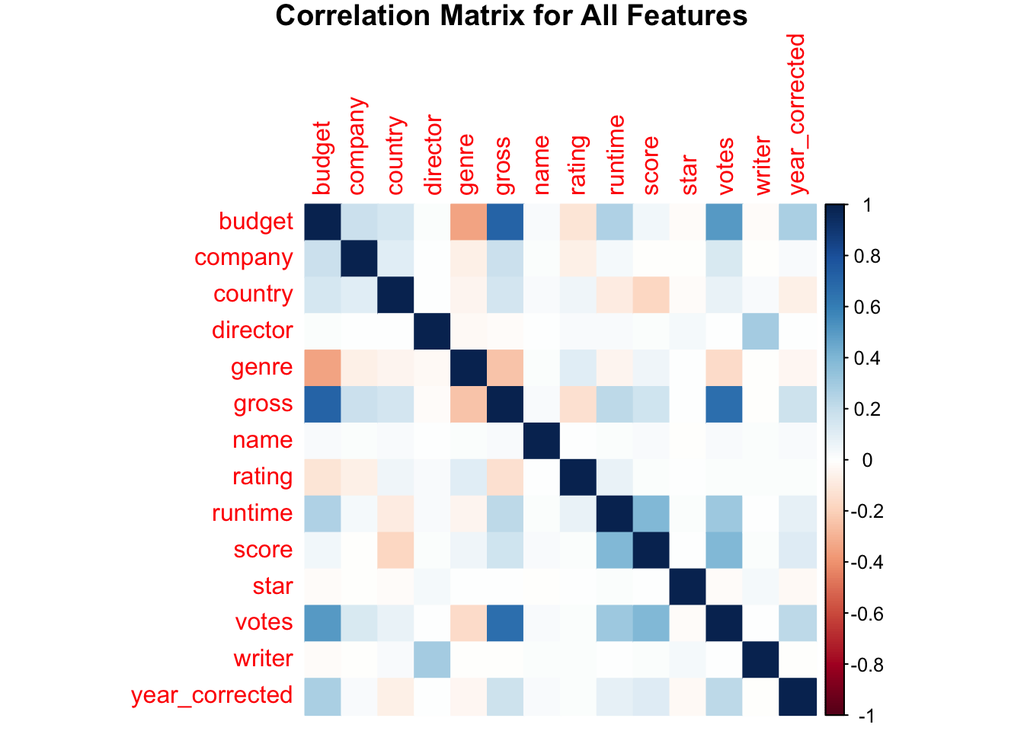

```r
cor_numfac_mx <- cor(df_numfac[,c(-9,-15)]) # creating correlation matrix
corrplot(cor_numfac_mx, method = "color", title = "Correlation Matrix for All Features",
         mar=c(0,0,1,0)) # correlation plot
```

It looks like both budget and votes are still the most highly correlated with gross earnings, both showing fairly strong positive correlation.

Finally, let’s look only at gross earnings in the correlation matrix

```r
cor_gross <- cor(df_numfac[,c(-6,-9,-15)], df_numfac$gross) # matrix of only correlation w/ gross
cor_gross <- as.matrix(cor_gross[order(cor_gross[,1], decreasing = T),]) # ordered by highest correlation
cor_gross
```

```
##                        [,1]
## budget          0.712195533
## votes           0.662457162
## runtime         0.224579126
## company         0.187127932
## year_corrected  0.176878717
## score           0.165692560
## country         0.152680021
## name            0.023786532
## star            0.008370577
## writer         -0.009471407
## director       -0.011461449
## rating         -0.135537645
## genre          -0.242676458
```

```r
colnames(cor_gross) <- c("gross") # changing column name

high_cor_gross <- cor_gross[cor_gross[,1] >= .5,, drop = F] # budget and votes have highest correlation w/ gross
high_cor_gross
```

```
##            gross
## budget 0.7121955
## votes  0.6624572
```

There you have it. Budget and votes have the highest correlation with gross earnings. This is about what you would expect, having a high budget for a movie generally produces a better product, thus earning more. It was interesting to learn the correlation between user votes and the gross earnings for a movie. I was somewhat surprised company did not have a higher correlation with gross earnings. I would have expected some companies, such as Disney, 20th Century Fox, Universal Pictures, etc. to have bring in more money based on their brand name.